# Ads_CTR_Optimisation

## Importing the libraries

```python
import pandas as pd
import numpy as np
import seaborn as sns
import re
import random
import math

import matplotlib.pyplot as plt
%matplotlib inline
from matplotlib.pylab import rcParams
rcParams['figure.figsize'] = 12, 7

from IPython.display import Image

# import warnings
# warnings.simplefilter(action='ignore', category=FutureWarning)
```

## Importing the dataset

```python
df = pd.read_csv('Ads_CTR_Optimisation.csv')
df.head()
```

|  | Ad 1 | Ad 2 | Ad 3 | Ad 4 | Ad 5 | Ad 6 | Ad 7 | Ad 8 | Ad 9 | Ad 10 |
| --- | --- | --- | --- | --- | --- | --- | --- | --- | --- | --- |
| 0 | 1 | 0 | 0 | 0 | 1 | 0 | 0 | 0 | 1 | 0 |
| 1 | 0 | 0 | 0 | 0 | 0 | 0 | 0 | 0 | 1 | 0 |
| 2 | 0 | 0 | 0 | 0 | 0 | 0 | 0 | 0 | 0 | 0 |
| 3 | 0 | 1 | 0 | 0 | 0 | 0 | 0 | 1 | 0 | 0 |
| 4 | 0 | 0 | 0 | 0 | 0 | 0 | 0 | 0 | 0 | 0 |

```python
df.shape
```

```
(10000, 10)
```

# Implementing Random Selection

```python
# import random
ads_selected1 = []
total_reward1 = 0
for n in range(0, df.shape[0]):
    ad = random.randrange(df.shape[1])
    ads_selected1.append(ad)
    reward = df.values[n, ad]
    total_reward1 = total_reward1 + reward
print('Total Reward = ',total_reward1)
```

```
Total Reward =  1279
```

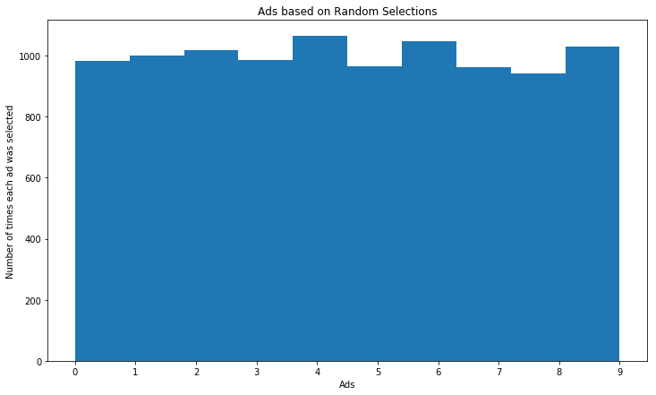

```python
# Visualising the results
plt.hist(ads_selected1)
plt.title('Ads based on Random Selections')
plt.xlabel('Ads')
plt.ylabel('Number of times each ad was selected')
plt.xticks(np.arange(0, df.shape[1], 1))
plt.show()
```

```python
for i in range(df.shape[1]):
    print('No. of times Ad {} was selected = {}'.format(i+1, ads_selected1.count(i)))
```

```
No. of times Ad 1 was selected = 983
No. of times Ad 2 was selected = 1000
No. of times Ad 3 was selected = 1017
No. of times Ad 4 was selected = 987
No. of times Ad 5 was selected = 1064
No. of times Ad 6 was selected = 966
No. of times Ad 7 was selected = 1047
No. of times Ad 8 was selected = 963
No. of times Ad 9 was selected = 942
No. of times Ad 10 was selected = 1031
```

[output not shown]

# Implementing Upper Confidence Bound (UCB)

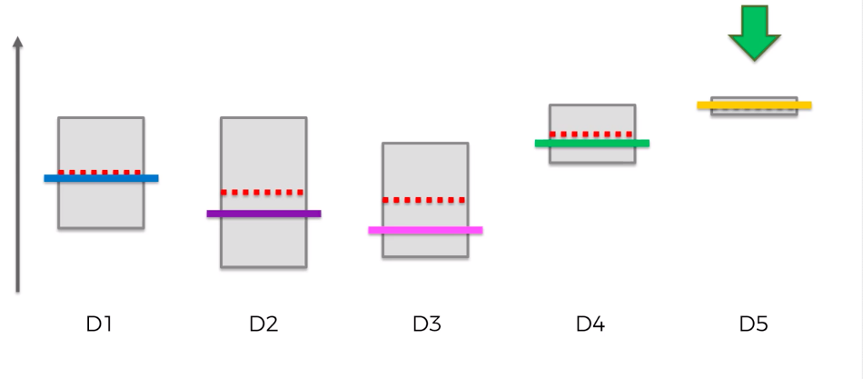

```python
# from IPython.display import Image
Image(filename='UCB_Algorithm_Slide_1.png')
```

The algorithm starts with an initial expecte value. Then, select a column and exploit it one time. The expected value might go down or up as new observation is taken. As there are more observations, the confidence bound gets smaller as the algorithm is more confident in the result. Then, select the column with the hiest upper confidence bound and exploit it once, which also makes the bound gets smaller and shifts the observation. Repeat these steps until the algorithm consistently exploits the same column, which is an indicator that this column is the optimal model.

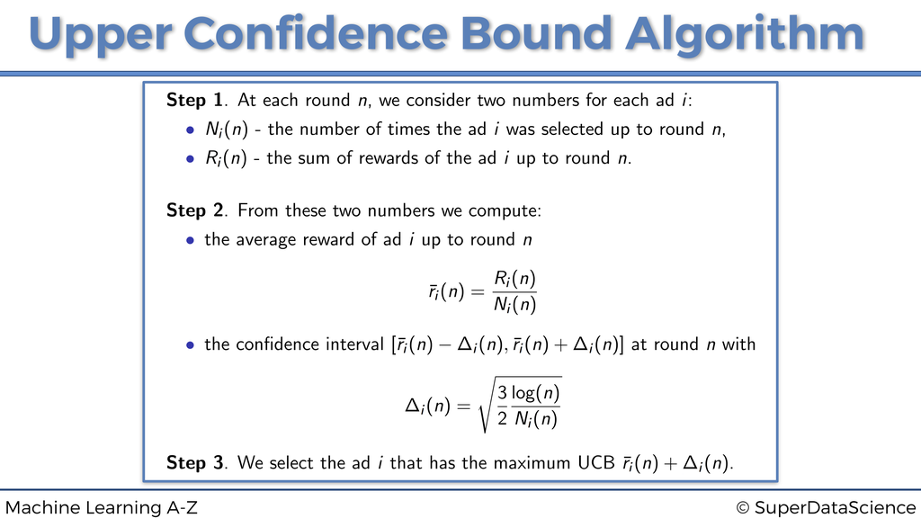

```python
# from IPython.display import Image
Image(filename='UCB_Algorithm_Slide_2.png')
```

```python
# import math
d = df.shape[1]
ads_selected2 = []
numbers_of_selections = [0] * d
sums_of_rewards = [0] * d
total_reward2 = 0
for n in range(0, df.shape[0]):
    ad = 0
    max_upper_bound = 0
    for i in range(0, d):
        if (numbers_of_selections[i] > 0):
            average_reward = sums_of_rewards[i] / numbers_of_selections[i]
            delta_i = math.sqrt(3/2 * math.log(n + 1) / numbers_of_selections[i])
            upper_bound = average_reward + delta_i
        else:
            upper_bound = 1e400
        if upper_bound > max_upper_bound:
            max_upper_bound = upper_bound
            ad = i
    ads_selected2.append(ad)
    numbers_of_selections[ad] = numbers_of_selections[ad] + 1
    reward = df.values[n, ad]
    sums_of_rewards[ad] = sums_of_rewards[ad] + reward
    total_reward2 = total_reward2 + reward
print('Total Reward = ',total_reward2)
```

```
Total Reward =  2178
```

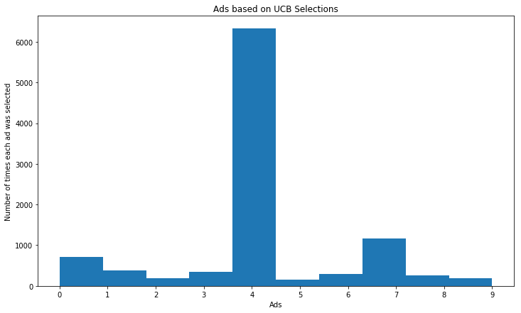

```python
# Visualising the results
plt.hist(ads_selected2)
plt.title('Ads based on UCB Selections')
plt.xlabel('Ads')
plt.ylabel('Number of times each ad was selected')
plt.xticks(np.arange(0, df.shape[1], 1))
plt.show()
```

```python
for i in range(df.shape[1]):
    print('No. of times Ad {} was selected = {}'.format(i+1, ads_selected2.count(i)))
```

```
No. of times Ad 1 was selected = 705
No. of times Ad 2 was selected = 387
No. of times Ad 3 was selected = 186
No. of times Ad 4 was selected = 345
No. of times Ad 5 was selected = 6323
No. of times Ad 6 was selected = 150
No. of times Ad 7 was selected = 292
No. of times Ad 8 was selected = 1170
No. of times Ad 9 was selected = 256
No. of times Ad 10 was selected = 186
```

[output not shown]

# Implementing Thompson/Posterior Sampling

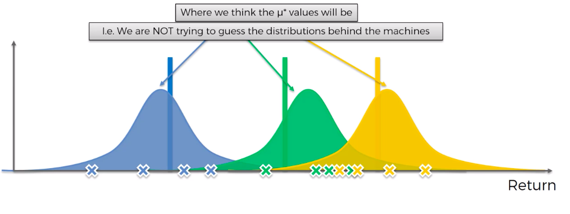

```python
# from IPython.display import Image
Image(filename='Thompson_Sampling_Slide_1.png')
```

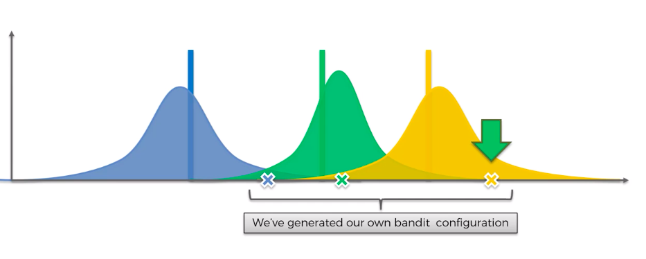

```python
# from IPython.display import Image
Image(filename='Thompson_Sampling_Slide_2.png')
```

Then, pick the best point which is the point that is on the far right side of the plot, as it has the highest return. Calculate it on the existing distribution and adjust the expected value and refine the distribution according to this. After iterating these steps many times, the graph will look like this:

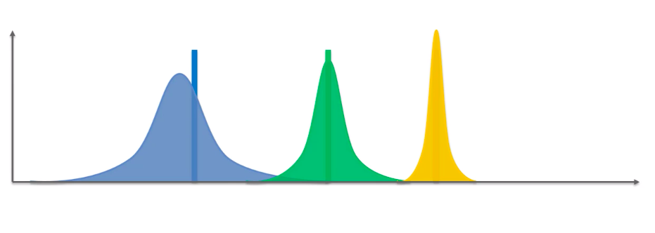

```python
# from IPython.display import Image
Image(filename='Thompson_Sampling_Slide_3.png')
```

The distributions are refined because of more observations present.

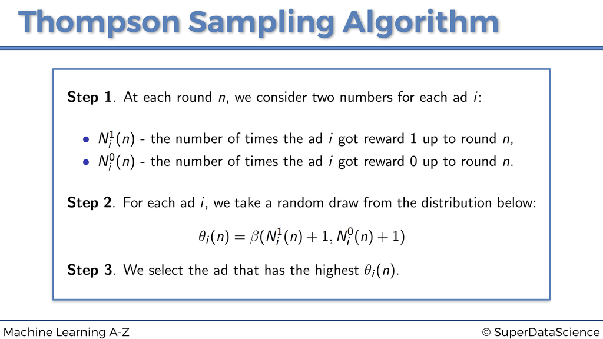

```python
# from IPython.display import Image
Image(filename='Thompson_Sampling_Slide_4.png')
```

```python
# import random
d = df.shape[1]
ads_selected3 = []
numbers_of_rewards_1 = [0] * d
numbers_of_rewards_0 = [0] * d
total_reward3 = 0
for n in range(0, df.shape[0]):
    ad = 0
    max_random = 0
    for i in range(0, d):
        random_beta = random.betavariate(numbers_of_rewards_1[i] + 1, numbers_of_rewards_0[i] + 1)
        if random_beta > max_random:
            max_random = random_beta
            ad = i
    ads_selected3.append(ad)
    reward = df.values[n, ad]
    if reward == 1:
        numbers_of_rewards_1[ad] = numbers_of_rewards_1[ad] + 1
    else:
        numbers_of_rewards_0[ad] = numbers_of_rewards_0[ad] + 1
    total_reward3 = total_reward3 + reward
print('Total Reward = ',total_reward3)
```

```
Total Reward =  2608
```

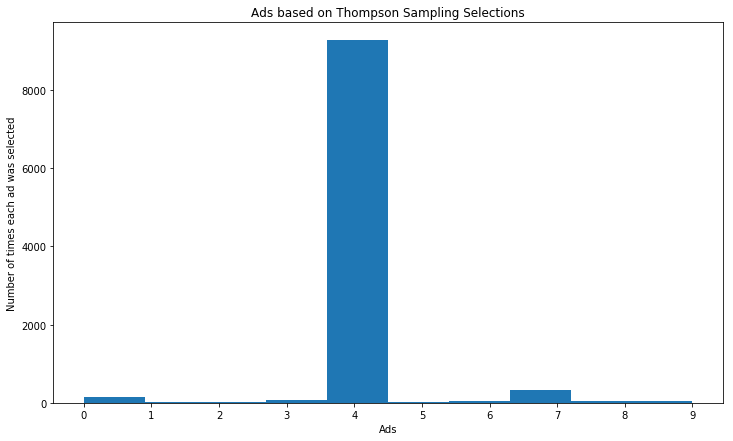

```python
# Visualising the results
plt.hist(ads_selected3)
plt.title('Ads based on Thompson Sampling Selections')
plt.xlabel('Ads')
plt.ylabel('Number of times each ad was selected')
plt.xticks(np.arange(0, df.shape[1], 1))
plt.show()
```

```python
for i in range(df.shape[1]):
    print('No. of times Ad {} was selected = {}'.format(i+1, ads_selected3.count(i)))
```

```
No. of times Ad 1 was selected = 157
No. of times Ad 2 was selected = 26
No. of times Ad 3 was selected = 26
No. of times Ad 4 was selected = 65
No. of times Ad 5 was selected = 9268
No. of times Ad 6 was selected = 25
No. of times Ad 7 was selected = 35
No. of times Ad 8 was selected = 325
No. of times Ad 9 was selected = 39
No. of times Ad 10 was selected = 34
```

[output not shown]

```
Comparison of UCB & Thompson Sampling
-> While UCB is deterministic, Thomson Sampling is probabilistic.
-> In UCB, the result needs to be updated every time.
   In Thompson, many samples can be chosen at once, & update the model later, which is computationally more efficient.
-> Thomson Sampling has better empirical evidence.
```